# Assignment 09: Final Project

## Computational Methods in Psychology and Neuroscience

### Psychology 4215/7215 --- Fall 2023

# Objectives

Upon completion of this assignment, students will have:

1. Described a list generation process in detail
2. Described the experiment details
3. Stated two new new hypotheses/questions to test
4. Visualized processed data testing these hypotheses
5. Performed a statistical analyses to test the hypotheses
6. Summarized the results

# Assignment

Write text (in MarkDown cells) and code (in Code cells) in a Jupyter notebook (after making a copy and renaming it to have your userid in the title --- e.g., A10_Final_Project_mst3k).

## Details

The goal of the final project is to synthesize material covered in the class and produce part of what would go into an actual scientific publication based on *one or more* of the experiments we ran in the class. Specifically, you will be writing part of the Methods and Results sections.

You can copy the basic template code for loading and processing the data from the class lessons. We also outline what each section of your assignment should include. In addition to describing the experiment in detail, you will be developing novel hypotheses we did not test in class and then performing the associated analyses and visualizing the results. As always, make sure to label all figures and be sure to refer to the code in the lesson notebooks as a guide for your analyses.

Please feel free to reach out to us on Discord if you have any questions along the way. For example, we're happy to weigh in on whether or not your hypotheses are novel.

- *If you select the project in this notebook, when you are done, save this notebook as HTML (`File -> Download as -> HTML`) and upload it to the matching assignment on UVA Canvas.*

## General Imports

```python
# import some useful libraries
import random
import csv
from copy import deepcopy
import pickle
import pandas as pd
import numpy as np
import statsmodels.formula.api as smf
import statsmodels.api as smc
from statsmodels.stats.api import anova_lm
import matplotlib.pyplot as plt
import seaborn as sns


from smile.common import *
from smile.scale import scale as s

from smile.common import *
from smile.scale import scale as s
from smile.math_distract import MathDistract
from smile.moving_dots import MovingDots
import plotnine as pn
import scipy.stats.distributions as dists
from scipy import stats
from glob import glob
import os
import arviz as az
import bambi as bmb

from smile.log import log2dl
```

[output not shown]

[output cut: 2082 more lines]

[output not shown]

# Hypotheses

1. I hypothesize that words that are presented in the middle of the test are more likely to be forgotten than the first three words presented and the last three words presented.

   > Serial position effect: Assess whether participants show a tendency to remember items at the beginning (primacy effect) or end (recency effect) of the list more accurately. This can provide insights into how the position of an item in a sequence affects memory recall.
2. I hypothesize that if the time difference between the study word presented from the test word is shorter, the participant will have a greater recall and accuracy than if the time series between the study list and test list is greater.

   > Retention over time: Test participants' ability to retain information over different time intervals. This can include short-term memory (immediate recall) and long-term memory (recall after a delay).

# Methods

## List generation

*Provide enough detail (in words) about the list generation so that someone could recreate the list generation code themselves. Be sure to state all the specific parameters used, including number of stimuli per block and number of blocks. Refer to the list generation code we provided to find all the information you need.*

## Refreshing Valence Study

In this study, participants engage in a recognition memory task involving words categorized by emotional valence (positive, negative, neutral). The experiment consists of three experimental conditions: Repeated, where a word is immediately presented again; Refreshed, where participants refresh the memory of the preceding word with a positive cue; and Once-presented, where a word is shown only once without repetition or refreshment. The study items are generated by shuffling combinations of valence and condition types. For Repeated and Refreshed conditions, two items are appended, while for Once-presented, only one item is added to the block. Additionally, matching test lists are created for each study list, encompassing studied items and valence-matched lure words. Each trial dictionary includes information on the word, its valence, the trial condition, and whether it is a target or a lure.

In summary, the study investigates the impact of emotional valence on recognition memory, exploring potential interactions with attention-refreshing cues. The experimental design involves manipulating valence and presentation conditions to create diverse study and test lists, ensuring a comprehensive examination of participants' memory performance and response patterns across different emotional contexts.

In creating the list generation, the researcher will first have to code a function. This is done by creating a definition or def name_of_function(x): create a dictionary reader, read in all the lines into a list of dictionaries, shuffle it so that we get new items each time, report out some pool information (by taking the length or len of the pool file, and finally return the shuffled pool.

The next code initializes a dictionary, "pools," to store shuffled word information from different valence pools. It reads and shuffles CSV files for positive, negative, and neutral valence conditions, storing them in the dictionary. The demonstration displays the first 5 items of the positive valence pool for a quick overview of the shuffled word order. The primary objective is to organize and prepare word pools for subsequent stages of the experiment, ensuring randomized order and facilitating access to valence-specific data.

Next, the researcher should define a function called `make_block` that generates a block of study and test trials based on the global variables and conditions. The function first creates a list of repeated conditions by iterating a specified number of times and extending the list of conditions (deepcopied from the global variable `conds`). It then shuffles the block conditions.

Next, it iterates over the block conditions and retrieves study and test items from the corresponding valence pool. It updates these items with the condition information, assigns presentation numbers and types, and appends them to the study and test lists. For conditions involving repetition or refreshing, it duplicates the study item, modifies relevant values, and appends it to the study list.

After processing all conditions, it shuffles the test list and returns a dictionary containing the study and test lists for the block.

To reproduce this code, define the function `make_block` and its inner logic. Set appropriate global variables like `num_reps`, `conds`, `val_conds`, `rep_conds`, `ref_text`, and `num_blocks`. Then, use a loop to generate the desired number of blocks, appending each block to the `blocks` list. This code facilitates the creation of multiple blocks of study and test trials based on experimental conditions.

Before executing the provided code, you must define several global variables. These are what create the inner logic for the definition of the make_block function. First, set num_reps to an integer representing the desired number of repetitions for each condition within a block. This variable controls how many times a word will be repeated or refreshed. Next, create val_conds, a list containing the valence conditions such as 'pos' for positive, 'neg' for negative, and 'neu' for neutral. Similarly, define rep_conds, a list enumerating the repetition conditions: 'repeat' for repeated, 'refresh' for refreshed, and 'once' for once-presented words. Set ref_text as a string describing refreshed conditions.

Additionally, establish num_blocks as an integer indicating the number of blocks you wish to generate for the experiment. Once these global variables are defined, incorporate the provided code into your script or Jupyter Notebook. This code creates a function called make_block() that generates a block of study and test lists. Finally, execute the loop to generate the desired number of blocks, resulting in the blocks list containing dictionaries, each representing a block with study and test lists.

For those with little python knowledge a more in depth breakdown of how to reproduce the code:

The provided code defines a Python function called `make_block()` and uses it to generate experiment blocks. Here's a detailed breakdown:

1. **Function Definition:**
   - `def make_block():`: This line declares a function named `make_block` with no parameters. The function generates a block containing study and test lists.
2. **Loop for Repeated Conditions:**
   - `block_conds = []`: Initializes an empty list to store conditions within the block.
   - `for i in range(num_reps):`: Iterates `num_reps` times to create repeated conditions within the block.
     - `block_conds.extend(deepcopy(conds))`: Extends `block_conds` by creating deep copies of global conditions (`conds`).
3. **Shuffling Conditions:**
   - `random.shuffle(block_conds)`: Shuffles the conditions within the block randomly.
4. **Loop for Adding Items:**
   - `study_list = []` and `test_list = []`: Initialize empty lists for study and test items within the block.
   - `for cond in block_conds:`: Iterates over conditions in the block.
     - `study_item` and `test_item`: Retrieve study and test items based on valence from global pools (`pools`).
     - `study_item.update(cond)` and `test_item.update(cond)`: Updates items with condition information.
     - Adding relevant information for study and test items:
       - `'pres_num'`: Set to 1 for both study and test items.
       - `'type'`: Set to 'target' for study items and 'lure' for test items.
     - Appending items to study and test lists:
       - `study_list.append(study_item)`: Adds study items to the study list.
       - `test_list.append(study_item)` and `test_list.append(test_item)`: Adds both study and test items to the test list.
5. **Processing Repetition and Refresh Conditions:**
   - `if cond['cond'] in ['refresh', 'repeat']:`: Checks if the condition involves repetition or refreshing.
     - `rep_item = deepcopy(study_item)`: Creates a deep copy of the study item.
     - Modifies `rep_item` with updated values for repeated presentation.
     - Changes the item description if refreshing.
     - Appends the modified item to the study list.
6. **Shuffling Test List:**
   - `random.shuffle(test_list)`: Shuffles the test list randomly.
7. **Returning Block Dictionary:**
   - `block = {'study': study_list, 'test': test_list}`: Creates a dictionary containing study and test lists.
   - `return block`: Returns the block dictionary from the function.
8. **Generating Blocks:**
   - `blocks = []`: Initializes an empty list to store generated blocks.
   - `for b in range(num_blocks):`: Iterates `num_blocks` times.
     - `blocks.append(make_block())`: Appends blocks generated by the `make_block()` function to the `blocks` list.

By executing the provided code, you will create a list of experiment blocks, each containing study and test lists with specified conditions and item details. The function facilitates the generation of these blocks based on global variables and conditions.

Next, you can check if your code works by typing blocks. This will output a dictionary of shuffled words from the different word pools.

Import the pickle module. Save the blocks list to a file using the following line: pickle.dump(blocks, open('refresh_blocks.pickle', 'wb')). Next, change the filename ('refresh_blocks.pickle') to your desired name or location.

Use the pickle.load() function with the appropriate filename or path ('refresh_blocks.pickle') to deserialize and load the contents of the pickle file. The 'rb' argument indicates that the file should be treated as a binary stream during the loading process.

To create the DataFrame sl from the study list of the first block in the experiment, you would first import the Pandas library with import pandas as pd. Then, you use the pd.DataFrame() function to convert the 'study' list into a structured table. In this case, blocks[0]['study'] accesses the 'study' list of the first block. Finally, you assign this DataFrame to the variable sl. The DataFrame will automatically organize the data into rows and columns, making it easier to work with and analyze.

## SMILE Experiment Details

*Provide enough detail so that someone could implement the experiment presentation and response collection, including all timing information and how the blocks were structured and presented.*

The task involves implementing a recognition memory experiment. Participants will study a list of items, and after a short delay, they will be tested on their memory of those items. The experiment consists of multiple blocks, each containing a study phase followed by a test phase. In each block:

1. Present instructions to the participant explaining the task.
2. Optionally provide practice for making responses.
3. Loop over the study--test lists within each block, waiting for a key press to start the block.
4. In the study phase, present study items one at a time, logging relevant information.
5. Wait for a delay, potentially filled with simple math problems.
6. In the test phase, present test items one at a time, waiting for a keyboard response for each item, and logging stimulus information and participant responses.

Each study item trial involves presenting the item for a specified duration, waiting for an inter-stimulus duration with jitter, and logging stimulus information. Each test item trial involves presenting the item until the participant responds with a key press indicating whether the item is "old" or "new," logging stimulus information and participant responses. The entire experiment can be implemented using a state machine, and breaking it into subroutines may enhance clarity and organization.

Next one should create code that outlines the creation of a recognition memory experiment using Smile, a Python library for cognitive neuroscience experiments. Here's a base-level overview of the steps:

1. **Setup and Configuration:**
   - Import necessary modules (Smile's common and scale modules).
   - Define configuration variables (font size, response keys, duration settings, etc.).
2. **Instructional Text:**
   - Create a detailed instructional text explaining the recognition memory task, response keys, and overall procedure.
3. **Experiment Creation:**
   - Use Smile's Experiment module to set up the experiment (participant details, screen settings, etc.).
4. **Subroutines:**
   - Define subroutines for specific tasks:
     - `Instruct`: Display instructions and wait for participant response.
     - `StudyList`: Present study trial words with logging.
     - `TestList`: Present test trial words with logging of responses.
5. **Simulation Start:**
   - Display a welcome label and wait for the participant to press ENTER.
   - Gather participant information using Smile's InputSubject function.
   - Show the instructions to the participant.
6. **Block Execution:**
   - Loop over each block of the experiment.
   - Display block-specific instructions and wait for the participant to start.
   - Introduce delays between different phases of the experiment.
7. **Trial Presentation and Logging:**
   - Loop over study trials in each block, presenting words and logging details.
   - Introduce delays between study and test trials.
   - Loop over test trials, presenting words, collecting responses, and logging details.
8. **Experiment Conclusion:**
   - Display a completion message and instruct the participant to press ENTER to finish the experiment.
9. **Run the Experiment:**
   - Execute the experiment using the `exp.run()` command.

This base-level overview provides a structured understanding of the experiment's flow, without delving into specific code lines.

# Results

## Data processing and visualization

### First Load in all the Data

```python
# custom function to load slogs
def load_all_subj_logs(data_dir, log_file):
    # load in a list of all the subj
    subjs = [os.path.splitext(os.path.split(filepath)[1])[0].split('_')[-1]
             for filepath in glob(os.path.join(data_dir, log_file + '*.slog'))]
    subjs.sort()

    # loop over subj and their data
    all_dat = []
    for subj in subjs:
        # set the file
        log_path = os.path.join(data_dir, log_file+'_'+subj+'.slog')
        #print(log_path)

        # load the data
        try:
            all_dat.extend(log2dl(log_path, subj=subj))
        except:
            pass

    df = pd.DataFrame(all_dat)

    return df
```

```python
pwd
```

```
'/Users/lexivanmetre/Desktop/Fall 2023/PSYC 4215/Assignments/refresh'
```

```python
# load the data from each task
data_dir = 'refresh_dat'
df_s = load_all_subj_logs(data_dir, 'log_refresh_study')
df_t = load_all_subj_logs(data_dir, 'log_refresh_test')
df_t.head()
```

|  | resp_map_target | resp_map_lure | block_num | trial_num | stim_on_time | stim_on_error | resp | resp_time_time | resp_time_error | rt | ... | arousal_sd | dominance_mean | dominance_sd | word_frequency | valence | cond | pres_num | type | subj | log_num |
| --- | --- | --- | --- | --- | --- | --- | --- | --- | --- | --- | --- | --- | --- | --- | --- | --- | --- | --- | --- | --- | --- |
| 0 | J | F | 0 | 0 | 141.686912 | 0.0 | J | 144.111953 | 0.000479 | 2.425040 | ... | 2.71 | 3.9300000000000002 | 2.29 | 38 | neg | repeat | 1 | target | s000 | 0 |
| 1 | J | F | 0 | 1 | 145.325594 | 0.0 | F | 146.409344 | 0.000517 | 1.083750 | ... | 2.6299999999999999 | 5.7999999999999998 | 2.1600000000000001 | 13 | pos | repeat | 1 | lure | s000 | 0 |
| 2 | J | F | 0 | 2 | 147.322170 | 0.0 | F | 148.306278 | 0.000450 | 0.984108 | ... | 2.3399999999999999 | 3.98 | 1.8999999999999999 | 3 | neg | refresh | 1 | lure | s000 | 0 |
| 3 | J | F | 0 | 3 | 149.190018 | 0.0 | F | 150.066530 | 0.002967 | 0.876512 | ... | 2.5899999999999999 | 6.4000000000000004 | 2.29 | 37 | pos | refresh | 1 | lure | s000 | 0 |
| 4 | J | F | 0 | 4 | 151.307007 | 0.0 | F | 152.004527 | 0.000440 | 0.697521 | ... | 2.4900000000000002 | 4.6799999999999997 | 1.8500000000000001 | 37 | neu | once | 1 | lure | s000 | 0 |

5 rows × 27 columns

```python
# add in log_rt columns
df_t['log_rt'] = np.log(df_t['rt'])

# must make correct an int
df_t['correct'] = df_t['correct'].astype(int)

# add in a column for whether they made an 'old' response
df_t['old_resp'] = (df_t['resp_map_target'] == df_t['resp']).astype(int)
```

### Some Data Cleanup

```python
# add in log_rt columns
df_t['log_rt'] = np.log(df_t['rt'])

# must make correct an int
df_t['correct'] = df_t['correct'].astype(int)

# add in a column for whether they made an 'old' response
df_t['old_resp'] = (df_t['resp_map_target'] == df_t['resp']).astype(int)
```

```python
df_t.head()
```

|  | resp_map_target | resp_map_lure | block_num | trial_num | stim_on_time | stim_on_error | resp | resp_time_time | resp_time_error | rt | ... | dominance_sd | word_frequency | valence | cond | pres_num | type | subj | log_num | log_rt | old_resp |
| --- | --- | --- | --- | --- | --- | --- | --- | --- | --- | --- | --- | --- | --- | --- | --- | --- | --- | --- | --- | --- | --- |
| 0 | J | F | 0 | 0 | 141.686912 | 0.0 | J | 144.111953 | 0.000479 | 2.425040 | ... | 2.29 | 38 | neg | repeat | 1 | target | s000 | 0 | 0.885848 | 1 |
| 1 | J | F | 0 | 1 | 145.325594 | 0.0 | F | 146.409344 | 0.000517 | 1.083750 | ... | 2.1600000000000001 | 13 | pos | repeat | 1 | lure | s000 | 0 | 0.080428 | 0 |
| 2 | J | F | 0 | 2 | 147.322170 | 0.0 | F | 148.306278 | 0.000450 | 0.984108 | ... | 1.8999999999999999 | 3 | neg | refresh | 1 | lure | s000 | 0 | -0.016020 | 0 |
| 3 | J | F | 0 | 3 | 149.190018 | 0.0 | F | 150.066530 | 0.002967 | 0.876512 | ... | 2.29 | 37 | pos | refresh | 1 | lure | s000 | 0 | -0.131805 | 0 |
| 4 | J | F | 0 | 4 | 151.307007 | 0.0 | F | 152.004527 | 0.000440 | 0.697521 | ... | 1.8500000000000001 | 37 | neu | once | 1 | lure | s000 | 0 | -0.360223 | 0 |

5 rows × 29 columns

```python
df_s.head()
```

|  | block_num | trial_num | stim_on_time | stim_on_error | log_time | description | word_no | valence_mean | valence_sd | arousal_mean | arousal_sd | dominance_mean | dominance_sd | word_frequency | valence | cond | pres_num | type | subj | log_num |
| --- | --- | --- | --- | --- | --- | --- | --- | --- | --- | --- | --- | --- | --- | --- | --- | --- | --- | --- | --- | --- |
| 0 | 0 | 0 | 37.675125 | 0.0 | 41.077569 | fat | 160 | 2.2799999999999998 | 1.9199999999999999 | 4.8099999999999996 | 2.7999999999999998 | 4.4699999999999998 | 3.0600000000000001 | 60 | neg | repeat | 1 | target | s000 | 0 |
| 1 | 0 | 1 | 41.112915 | 0.0 | 44.202461 | fat | 160 | 2.2799999999999998 | 1.9199999999999999 | 4.8099999999999996 | 2.7999999999999998 | 4.4699999999999998 | 3.0600000000000001 | 60 | neg | repeat | 2 | target | s000 | 0 |
| 2 | 0 | 2 | 44.224780 | 0.0 | 47.367469 | sugar | 1002 | 6.7400000000000002 | 1.73 | 5.6399999999999997 | 2.1800000000000002 | 5.5 | 1.5 | 34 | pos | once | 1 | target | s000 | 0 |
| 3 | 0 | 3 | 47.397376 | 0.0 | 50.472568 | ignorance | 803 | 3.0699999999999998 | 2.25 | 4.3899999999999997 | 2.4900000000000002 | 4.4100000000000001 | 2.3799999999999999 | 16 | neg | once | 1 | target | s000 | 0 |
| 4 | 0 | 4 | 50.495049 | 0.0 | 53.504258 | nude | 520 | 6.8200000000000003 | 1.6299999999999999 | 6.4100000000000001 | 2.0899999999999999 | 5.96 | 2.29 | 20 | pos | repeat | 1 | target | s000 | 0 |

```python
df_s.columns
```

```
Index(['block_num', 'trial_num', 'stim_on_time', 'stim_on_error', 'log_time',
       'description', 'word_no', 'valence_mean', 'valence_sd', 'arousal_mean',
       'arousal_sd', 'dominance_mean', 'dominance_sd', 'word_frequency',
       'valence', 'cond', 'pres_num', 'type', 'subj', 'log_num'],
      dtype='object')
```

```python
df_t.columns
```

```
Index(['resp_map_target', 'resp_map_lure', 'block_num', 'trial_num',
       'stim_on_time', 'stim_on_error', 'resp', 'resp_time_time',
       'resp_time_error', 'rt', 'correct', 'log_time', 'description',
       'word_no', 'valence_mean', 'valence_sd', 'arousal_mean', 'arousal_sd',
       'dominance_mean', 'dominance_sd', 'word_frequency', 'valence', 'cond',
       'pres_num', 'type', 'subj', 'log_num', 'log_rt', 'old_resp'],
      dtype='object')
```

```python
correct_mean_perSubj = df_t.groupby(['subj', 'cond'])['correct'].mean()
correct_mean_perSubj
```

```
subj  cond
s000  once       0.763889
      refresh    0.777778
      repeat     0.791667
s001  once       0.736111
      refresh    0.750000
                   ...
s022  refresh    0.875000
      repeat     0.944444
s023  once       0.847222
      refresh    0.805556
      repeat     0.888889
Name: correct, Length: 72, dtype: float64
```

# Testing for Hypothesis I: Probability of Correct vs. Serial Position

Does the position of words within the test list, specifically those presented in the middle, have a significant impact on the likelihood of forgetting compared to the first three words and the last three words presented?

**Dependent Variable**: "Probability of Correct" representing the likelihood or probability of participants providing a correct response during the study.

**Independent Variable**: "trial number in the study" or "the serial position" indicating the specific order or placement of a word within the study list or trial sequence.

```python
# Looping through to find the presentation number and the time they appeared in each study

df_t['trial_num_in_study'] = -1  # Create a new column for 'trial_num' in the test DataFrame
trial_num_series = []

for ind, row in df_t.loc[df_t['type'] == 'target'].iterrows():
    matching_subj = df_s['subj'] == row['subj']
    matching_word = df_s['description'] == row['description']
    first_pres = df_s['pres_num'] == 1

    # Directly access the value of 'trial_num'
    trial_num_s = df_s.loc[matching_subj & matching_word & first_pres, 'trial_num'].values

    if len(trial_num_s) > 0:
        trial_num = trial_num_s[0]
        trial_num_series.append(trial_num)

# Assign the calculated 'trial_num' values to the 'trial_num_in_study' column
df_t.loc[df_t['type'] == 'target', 'trial_num_in_study'] = trial_num_series
```

```python
df_t
```

|  | resp_map_target | resp_map_lure | block_num | trial_num | stim_on_time | stim_on_error | resp | resp_time_time | resp_time_error | rt | ... | word_frequency | valence | cond | pres_num | type | subj | log_num | log_rt | old_resp | trial_num_in_study |
| --- | --- | --- | --- | --- | --- | --- | --- | --- | --- | --- | --- | --- | --- | --- | --- | --- | --- | --- | --- | --- | --- |
| 0 | J | F | 0 | 0 | 141.686912 | 0.0 | J | 144.111953 | 0.000479 | 2.425040 | ... | 38 | neg | repeat | 1 | target | s000 | 0 | 0.885848 | 1 | 12 |
| 1 | J | F | 0 | 1 | 145.325594 | 0.0 | F | 146.409344 | 0.000517 | 1.083750 | ... | 13 | pos | repeat | 1 | lure | s000 | 0 | 0.080428 | 0 | -1 |
| 2 | J | F | 0 | 2 | 147.322170 | 0.0 | F | 148.306278 | 0.000450 | 0.984108 | ... | 3 | neg | refresh | 1 | lure | s000 | 0 | -0.016020 | 0 | -1 |
| 3 | J | F | 0 | 3 | 149.190018 | 0.0 | F | 150.066530 | 0.002967 | 0.876512 | ... | 37 | pos | refresh | 1 | lure | s000 | 0 | -0.131805 | 0 | -1 |
| 4 | J | F | 0 | 4 | 151.307007 | 0.0 | F | 152.004527 | 0.000440 | 0.697521 | ... | 37 | neu | once | 1 | lure | s000 | 0 | -0.360223 | 0 | -1 |
| ... | ... | ... | ... | ... | ... | ... | ... | ... | ... | ... | ... | ... | ... | ... | ... | ... | ... | ... | ... | ... | ... |
| 5179 | F | J | 5 | 31 | 569589.682868 | 0.0 | J | 569592.197660 | 0.000716 | 2.514792 | ... | 7 | neg | repeat | 1 | lure | s023 | 0 | 0.922190 | 0 | -1 |
| 5180 | F | J | 5 | 32 | 569593.116104 | 0.0 | F | 569593.872080 | 0.008685 | 0.755975 | ... | . | neu | refresh | 1 | target | s023 | 0 | -0.279746 | 1 | 20 |
| 5181 | F | J | 5 | 33 | 569594.982806 | 0.0 | J | 569595.600502 | 0.000522 | 0.617696 | ... | 58 | pos | once | 1 | lure | s023 | 0 | -0.481759 | 0 | -1 |
| 5182 | F | J | 5 | 34 | 569596.747603 | 0.0 | F | 569597.725732 | 0.000589 | 0.978128 | ... | 3 | neu | repeat | 1 | target | s023 | 0 | -0.022114 | 1 | 27 |
| 5183 | F | J | 5 | 35 | 569598.615168 | 0.0 | J | 569599.232194 | 0.000429 | 0.617025 | ... | 123 | pos | refresh | 1 | lure | s023 | 0 | -0.482845 | 0 | -1 |

5184 rows × 30 columns

```python
df_t['trial_num_in_study'].max()
```

```
29
```

```python
df_t['trial_num_in_study'].min()
```

```
-1
```

```python
target_data = df_t.loc[df_t['type'] == 'target']
```

```python
# Version 1 : Serial Position
# Bin A or Beginning Words -- first 5 words
# Bin B or Middle Words -- middle 20 words
# Bin C or Last Words -- last 5 words

import numpy as np
# Define conditions
condition_beg = target_data['trial_num_in_study'] <= 4
condition_middle = (target_data['trial_num_in_study'] > 4) & (target_data['trial_num_in_study'] <= 24)
condition_last = target_data['trial_num_in_study'] > 24

# Define corresponding labels
labels = ['beg_word', 'middle_word', 'last_word']

# Use numpy.select to create a new column with labels
target_data['word_category'] = np.select([condition_beg, condition_middle, condition_last], labels, default='Unknown')

# Display the updated DataFrame
print(target_data[['type', 'trial_num_in_study', 'word_category']])
```

```
        type  trial_num_in_study word_category
0     target                  12   middle_word
5     target                  16   middle_word
6     target                  19   middle_word
8     target                  10   middle_word
13    target                   4      beg_word
...      ...                 ...           ...
5175  target                  11   middle_word
5177  target                   8   middle_word
5178  target                  25     last_word
5180  target                  20   middle_word
5182  target                  27     last_word

[2592 rows x 3 columns]
```

# Hypothesis I:

## Testing the Primacy and Recency Effect

100.00% [8000/8000 00:04<00:00 Sampling 4 chains, 0 divergences]

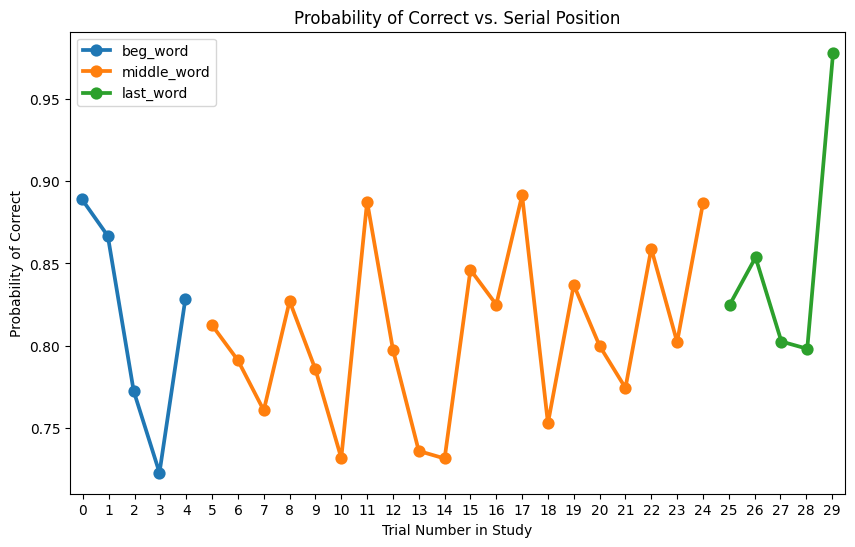

```python
# NEXT USING BAMBI
# Create a plot that on the y axis plots correct or incorrect
# the bins are the independent variable
# the x axis is call the serial position

# If hypothesis is correct, we should see that the first and last words have a higher mean correct
# than the middle words

import bambi as bmb
import seaborn as sns
import matplotlib.pyplot as plt

# Create a Bambi model
model = bmb.Model("correct ~ C(word_category, Treatment('beg_word')) + trial_num_in_study", target_data)

# Fit the model
results = model.fit()

# Create a plot using seaborn
plt.figure(figsize=(10, 6))
sns.pointplot(x='trial_num_in_study', y='correct', hue='word_category', data=target_data, dodge=True, ci=None, markers='o')

# Customize the plot
plt.xlabel('Trial Number in Study')
plt.ylabel('Probability of Correct')
plt.title('Probability of Correct vs. Serial Position')
plt.legend()
plt.show()
```

100.00% [8000/8000 00:04<00:00 Sampling 4 chains, 0 divergences]

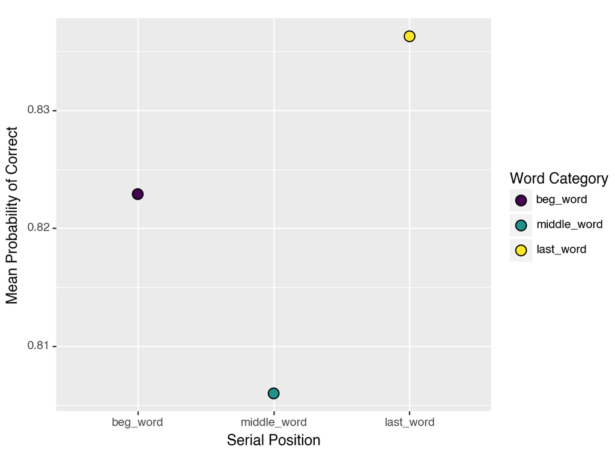

```
<Figure Size: (640 x 480)>
```

```python
model = bmb.Model("correct ~ C(word_category, Treatment('beg_word')) + trial_num_in_study", target_data)

# Fit the model
results = model.fit()

# Calculate mean correct for each word category
mean_data = target_data.groupby('word_category')['correct'].mean().reset_index()

# Specify the order of the levels for 'word_category_v3'
order = ['beg_word', 'middle_word', 'last_word']
mean_data['word_category'] = pd.Categorical(mean_data['word_category'], categories=order, ordered=True)

# Create a plot using plotnine
correctness_plot = (pn.ggplot(mean_data, pn.aes('word_category', 'correct', fill='word_category'))
     + pn.geom_point(position=pn.position_dodge(.9), size=4)
     + pn.labs(x="Serial Position", y="Mean Probability of Correct", fill='Word Category')
)

correctness_plot
```

## Hypothesis I, Version 2:

### To make sure there is no bias, we will make each serial position group contain the same number of words

```python
# To make sure there is no bias, we will make each group contain the same number of words
# Version 2 : Serial Position
# Bin A or First words -- 10 words
# Bin B or Middle words -- 10 words
# Bin C or Last Words -- 10 words

# Define conditions
condition_beg2 = target_data['trial_num_in_study'] <= 9
condition_middle2 = (target_data['trial_num_in_study'] > 9) & (target_data['trial_num_in_study'] <= 19)
condition_last2 = target_data['trial_num_in_study'] > 19

# Define corresponding labels
labels = ['beg_word2', 'middle_word2', 'last_word2']

# Use numpy.select to create a new column with labels
target_data['word_category_v2'] = np.select([condition_beg2, condition_middle2, condition_last2], labels, default='Unknown')

# Display the updated DataFrame
print(target_data[['type', 'trial_num_in_study', 'word_category_v2', 'correct']])
```

```
        type  trial_num_in_study word_category_v2  correct
0     target                  12     middle_word2        1
5     target                  16     middle_word2        1
6     target                  19     middle_word2        1
8     target                  10     middle_word2        1
13    target                   4        beg_word2        1
...      ...                 ...              ...      ...
5175  target                  11     middle_word2        1
5177  target                   8        beg_word2        1
5178  target                  25       last_word2        1
5180  target                  20       last_word2        1
5182  target                  27       last_word2        1

[2592 rows x 4 columns]
```

100.00% [8000/8000 00:05<00:00 Sampling 4 chains, 0 divergences]

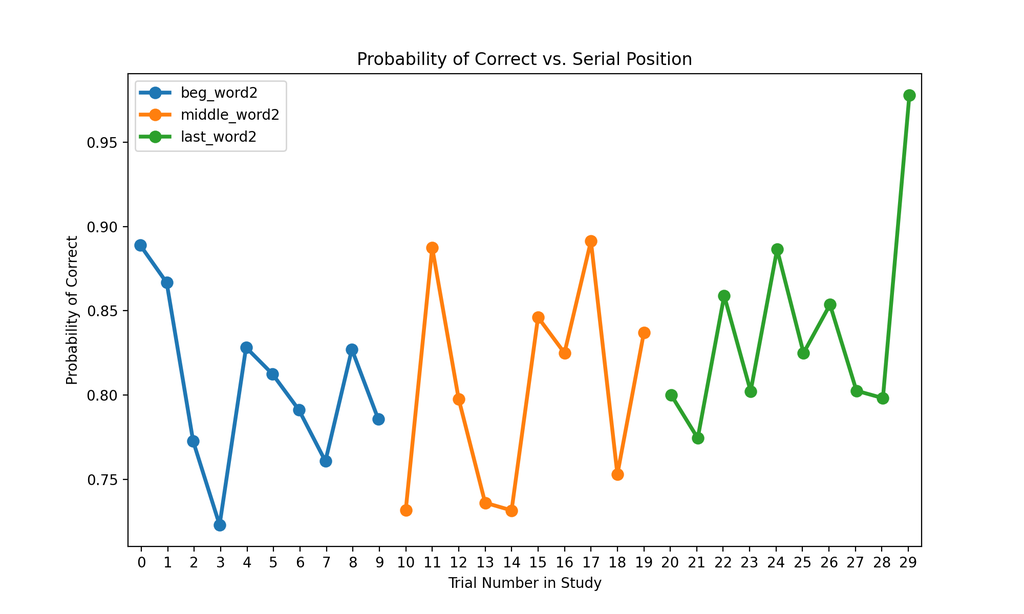

```python
# Create a Bambi model
model2 = bmb.Model("correct ~ C(word_category_v2, Treatment('beg_word2')) + trial_num_in_study", target_data)

# Fit the model
results = model2.fit()

# Create a plot using seaborn
plt.figure(figsize=(10, 6))
sns.pointplot(x='trial_num_in_study', y='correct', hue='word_category_v2', data=target_data, dodge=True, ci=None, markers='o')

# Customize the plot
plt.xlabel('Trial Number in Study')
plt.ylabel('Probability of Correct')
plt.title('Probability of Correct vs. Serial Position')
plt.legend()
plt.show()
```

100.00% [8000/8000 00:05<00:00 Sampling 4 chains, 0 divergences]

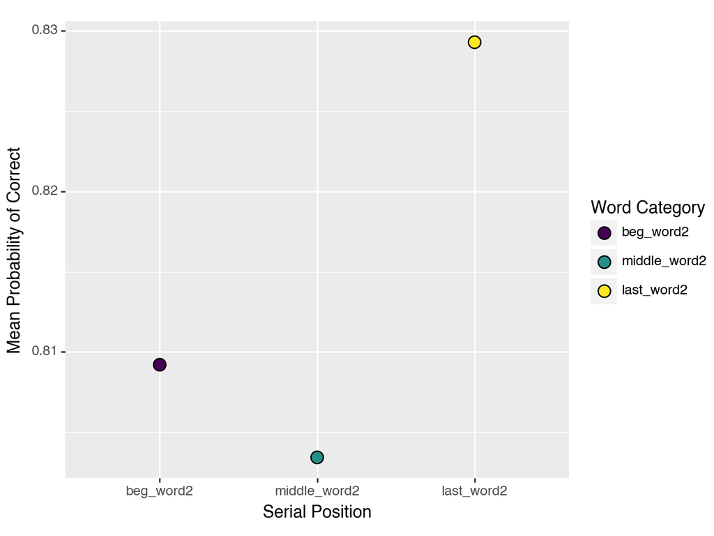

```
<Figure Size: (640 x 480)>
```

```python
model2 = bmb.Model("correct ~ C(word_category_v2, Treatment('beg_word2')) + trial_num_in_study", target_data)

# Fit the model
results = model2.fit()

# Calculate mean correct for each word category
mean_data = target_data.groupby('word_category_v2')['correct'].mean().reset_index()

# Specify the order of the levels for 'word_category_v3'
order = ['beg_word2', 'middle_word2', 'last_word2']
mean_data['word_category_v2'] = pd.Categorical(mean_data['word_category_v2'], categories=order, ordered=True)

# Create a plot using plotnine
correctness_plot = (pn.ggplot(mean_data, pn.aes('word_category_v2', 'correct', fill='word_category_v2'))
     + pn.geom_point(position=pn.position_dodge(.9), size=4)
     + pn.labs(x="Serial Position", y="Mean Probability of Correct", fill='Word Category')
)

correctness_plot
```

## Hypothesis I, Version 3:

### To ensure the primacy effect and recency effect are actually occuring we will make the first group and last group even smaller than Version 1.

```python
# Version 3
# Version 3 : Serial Position
# Bin A or Beginning Words -- first 3 words
# Bin B or Middle Words -- middle 24 words
# Bin C or Last Words -- last 3 words

import numpy as np
# Define conditions
condition_beg = target_data['trial_num_in_study'] <= 2
condition_middle = (target_data['trial_num_in_study'] > 2) & (target_data['trial_num_in_study'] <= 26)
condition_last = target_data['trial_num_in_study'] > 26

# Define corresponding labels
labels = ['beg_word3', 'middle_word3', 'last_word3']

# Use numpy.select to create a new column with labels
target_data['word_category_v3'] = np.select([condition_beg, condition_middle, condition_last], labels, default='Unknown')

# Display the updated DataFrame
print(target_data[['type', 'trial_num_in_study', 'word_category_v3']])
```

```
        type  trial_num_in_study word_category_v3
0     target                  12     middle_word3
5     target                  16     middle_word3
6     target                  19     middle_word3
8     target                  10     middle_word3
13    target                   4     middle_word3
...      ...                 ...              ...
5175  target                  11     middle_word3
5177  target                   8     middle_word3
5178  target                  25     middle_word3
5180  target                  20     middle_word3
5182  target                  27       last_word3

[2592 rows x 3 columns]
```

100.00% [8000/8000 00:03<00:00 Sampling 4 chains, 0 divergences]

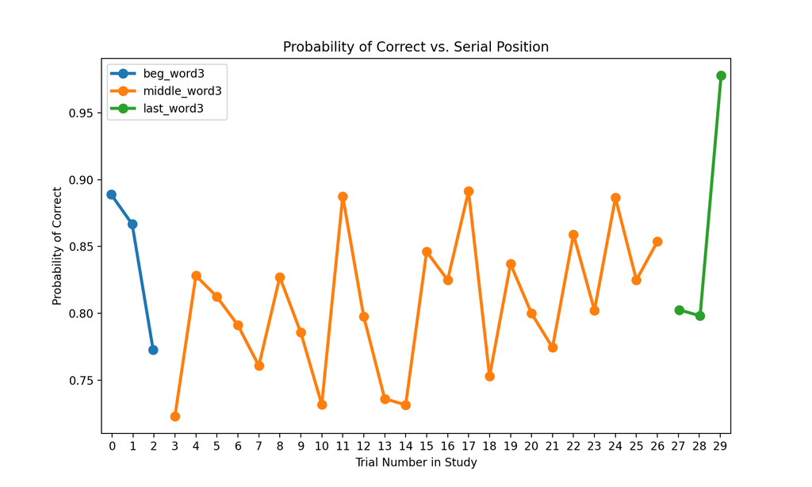

```python
# Create a Bambi model
model3 = bmb.Model("correct ~ C(word_category_v3, Treatment('beg_word3')) + trial_num_in_study", target_data)

# Fit the model
results = model3.fit()

# Create a plot using seaborn
plt.figure(figsize=(10, 6))
sns.pointplot(x='trial_num_in_study', y='correct', hue='word_category_v3', data=target_data, dodge=True, ci=None, markers='o')

# Customize the plot
plt.xlabel('Trial Number in Study')
plt.ylabel('Probability of Correct')
plt.title('Probability of Correct vs. Serial Position')
plt.legend()
plt.show()
```

100.00% [8000/8000 00:03<00:00 Sampling 4 chains, 0 divergences]

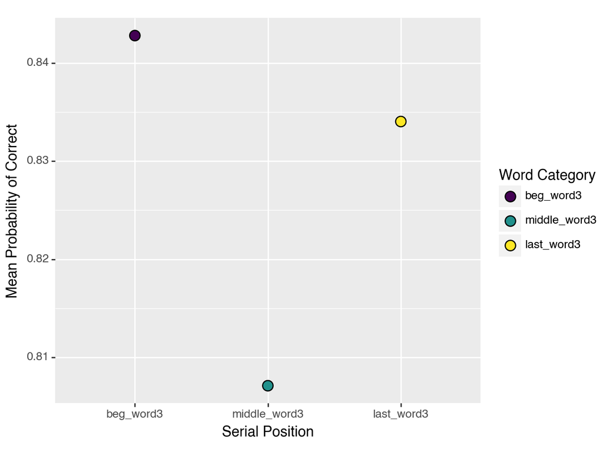

```
<Figure Size: (640 x 480)>
```

```python
model3 = bmb.Model("correct ~ C(word_category_v3, Treatment('beg_word3')) + trial_num_in_study", target_data)

# Fit the model
results = model3.fit()

# Calculate mean correct for each word category
mean_data = target_data.groupby('word_category_v3')['correct'].mean().reset_index()

# Specify the order of the levels for 'word_category_v3'
order = ['beg_word3', 'middle_word3', 'last_word3']
mean_data['word_category_v3'] = pd.Categorical(mean_data['word_category_v3'], categories=order, ordered=True)

# Create a plot using plotnine
correctness_plot = (pn.ggplot(mean_data, pn.aes('word_category_v3', 'correct', fill='word_category_v3'))
     + pn.geom_point(position=pn.position_dodge(.9), size=4)
     + pn.labs(x="Serial Position", y="Mean Probability of Correct", fill='Word Category')
)

correctness_plot
```

# Statistical Test and Interpretation

```python
formula = "correct ~ C(word_category_v3, Treatment('beg_word3')) + trial_num_in_study"
model_serialPosition = smf.ols(formula, target_data).fit()

# Display the summary of the linear regression model
print(model_serialPosition.summary())
```

```
                            OLS Regression Results
==============================================================================
Dep. Variable:                correct   R-squared:                       0.003
Model:                            OLS   Adj. R-squared:                  0.002
Method:                 Least Squares   F-statistic:                     2.362
Date:                Fri, 08 Dec 2023   Prob (F-statistic):             0.0694
Time:                        17:55:35   Log-Likelihood:                -1229.6
No. Observations:                2592   AIC:                             2467.
Df Residuals:                    2588   BIC:                             2491.
Df Model:                           3
Covariance Type:            nonrobust
===============================================================================================================================
                                                                  coef    std err          t      P>|t|      [0.025      0.975]
-------------------------------------------------------------------------------------------------------------------------------
Intercept                                                       0.8405      0.023     37.304      0.000       0.796       0.885
C(word_category_v3, Treatment('beg_word3'))[T.last_word3]      -0.0777      0.048     -1.624      0.104      -0.171       0.016
C(word_category_v3, Treatment('beg_word3'))[T.middle_word3]    -0.0705      0.029     -2.390      0.017      -0.128      -0.013
trial_num_in_study                                              0.0026      0.001      2.044      0.041       0.000       0.005
==============================================================================
Omnibus:                      616.435   Durbin-Watson:                   1.663
Prob(Omnibus):                  0.000   Jarque-Bera (JB):             1149.930
Skew:                          -1.604   Prob(JB):                    1.98e-250
Kurtosis:                       3.592   Cond. No.                         120.
==============================================================================

Notes:
[1] Standard Errors assume that the covariance matrix of the errors is correctly specified.
```

```python
import statsmodels.api as sm
import statsmodels.formula.api as smf

# Run a type-II repeated measures ANOVA based on the linear model results
sm.stats.anova_lm(model_serialPosition, typ=2)
```

|  | sum_sq | df | F | PR(>F) |
| --- | --- | --- | --- | --- |
| C(word_category_v3, Treatment('beg_word3')) | 0.880920 | 2.0 | 2.908505 | 0.054736 |
| trial_num_in_study | 0.632799 | 1.0 | 4.178580 | 0.041039 |
| Residual | 391.923325 | 2588.0 | NaN | NaN |

# Testing for Hypothesis II:

## Probability of Correct vs. Length in Time Since Study Word

Does the recall and accuracy of participants vary based on the time difference between the presentation of study words and test words, with the expectation that shorter time differences lead to greater recall and accuracy compared to longer time intervals?

**Dependent Variable**: The probability of correctness in recalling a word during the test phase.

**Independent Variable**: The time since the study, representing the duration between the initial presentation of a word in the study phase and its reappearance in the test phase.

```python
# Loop through each test stim appear time and use .loc to pull the same word in the study list

df_t['stim_time_diff'] = 0
time_series = []
for ind, row in df_t.loc[df_t.type=='target'].iterrows():
    matching_subj = (df_s['subj'] == row['subj'])
    matching_word = (df_s['description'] == row['description'])
    first_pres = df_s['pres_num'] == 1
    time_s = df_s.loc[matching_subj & matching_word & first_pres, 'stim_on_time']
    time_diff = np.array((row['stim_on_time'] - time_s))
    time_series.append(time_diff)
df_t.loc[df_t.type=='target', 'stim_time_diff'] = time_series
```

```python
df_t.head()
```

|  | resp_map_target | resp_map_lure | block_num | trial_num | stim_on_time | stim_on_error | resp | resp_time_time | resp_time_error | rt | ... | valence | cond | pres_num | type | subj | log_num | log_rt | old_resp | trial_num_in_study | stim_time_diff |
| --- | --- | --- | --- | --- | --- | --- | --- | --- | --- | --- | --- | --- | --- | --- | --- | --- | --- | --- | --- | --- | --- |
| 0 | J | F | 0 | 0 | 141.686912 | 0.0 | J | 144.111953 | 0.000479 | 2.425040 | ... | neg | repeat | 1 | target | s000 | 0 | 0.885848 | 1 | 12 | 66.35775 |
| 1 | J | F | 0 | 1 | 145.325594 | 0.0 | F | 146.409344 | 0.000517 | 1.083750 | ... | pos | repeat | 1 | lure | s000 | 0 | 0.080428 | 0 | -1 | 0.00000 |
| 2 | J | F | 0 | 2 | 147.322170 | 0.0 | F | 148.306278 | 0.000450 | 0.984108 | ... | neg | refresh | 1 | lure | s000 | 0 | -0.016020 | 0 | -1 | 0.00000 |
| 3 | J | F | 0 | 3 | 149.190018 | 0.0 | F | 150.066530 | 0.002967 | 0.876512 | ... | pos | refresh | 1 | lure | s000 | 0 | -0.131805 | 0 | -1 | 0.00000 |
| 4 | J | F | 0 | 4 | 151.307007 | 0.0 | F | 152.004527 | 0.000440 | 0.697521 | ... | neu | once | 1 | lure | s000 | 0 | -0.360223 | 0 | -1 | 0.00000 |

5 rows × 31 columns

```python
df_t['stim_time_diff'].max()
```

```
277.12504119996447
```

```python
df_t.loc[df_t.type=='target', 'stim_time_diff'].min()
```

```
11.314129832200706
```

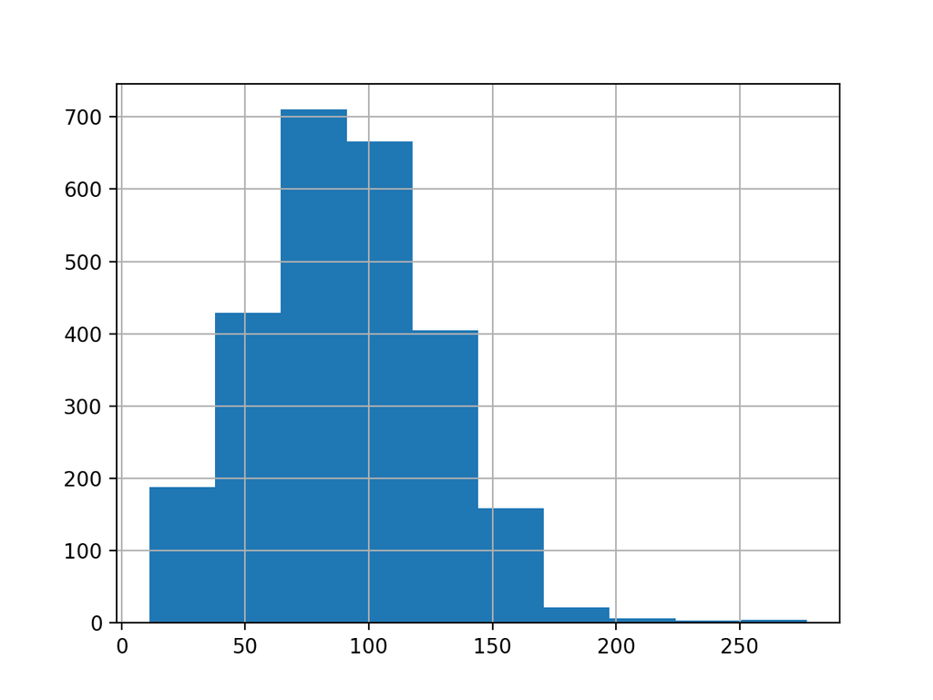

```python
df_t.loc[df_t.type=='target', 'stim_time_diff'].hist()
```

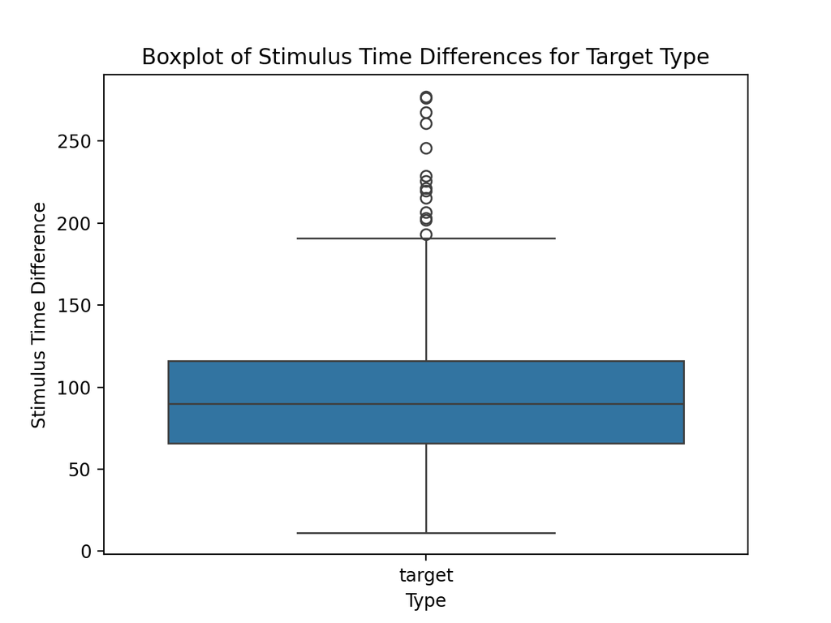

```python
import seaborn as sns

# Assuming df_t is your DataFrame
sns.boxplot(x='type', y='stim_time_diff', data=df_t[df_t['type'] == 'target'])
plt.xlabel('Type')
plt.ylabel('Stimulus Time Difference')
plt.title('Boxplot of Stimulus Time Differences for Target Type')
plt.show()
```

```python
df_t.columns
```

```
Index(['resp_map_target', 'resp_map_lure', 'block_num', 'trial_num',
       'stim_on_time', 'stim_on_error', 'resp', 'resp_time_time',
       'resp_time_error', 'rt', 'correct', 'log_time', 'description',
       'word_no', 'valence_mean', 'valence_sd', 'arousal_mean', 'arousal_sd',
       'dominance_mean', 'dominance_sd', 'word_frequency', 'valence', 'cond',
       'pres_num', 'type', 'subj', 'log_num', 'log_rt', 'old_resp',
       'trial_num_in_study', 'stim_time_diff'],
      dtype='object')
```

```python
import numpy as np

# Assuming df_t is your DataFrame and 'stim_time_diff' is the column of interest

# Calculate the median
median = np.median(df_t['stim_time_diff'])

# Calculate the interquartile range (IQR)
q1 = np.percentile(df_t['stim_time_diff'], 25)
q3 = np.percentile(df_t['stim_time_diff'], 75)
iqr = q3 - q1

# Print the results
print(f"Median: {median}")
print(f"IQR: {iqr}")
print(q1)
print(q3)
```

```
Median: 5.657064916100353
IQR: 90.06391485425058
0.0
90.06391485425058
```

```python
df_t.columns
```

```
Index(['resp_map_target', 'resp_map_lure', 'block_num', 'trial_num',
       'stim_on_time', 'stim_on_error', 'resp', 'resp_time_time',
       'resp_time_error', 'rt', 'correct', 'log_time', 'description',
       'word_no', 'valence_mean', 'valence_sd', 'arousal_mean', 'arousal_sd',
       'dominance_mean', 'dominance_sd', 'word_frequency', 'valence', 'cond',
       'pres_num', 'type', 'subj', 'log_num', 'log_rt', 'old_resp',
       'trial_num_in_study', 'stim_time_diff'],
      dtype='object')
```

```python
# Time Since Study Groups
# Bin A or Shortest Stim_Time diff -- stim_time_diff < 65
# Bin B or Middle Stim_time diff -- 65 < stim_time_diff < 115
# Bin C or Longest stim_time_diff -- stim_time_diff > 115

target_data = df_t.loc[df_t['type'] == 'target']
```

```python
target_data.columns
```

```
Index(['resp_map_target', 'resp_map_lure', 'block_num', 'trial_num',
       'stim_on_time', 'stim_on_error', 'resp', 'resp_time_time',
       'resp_time_error', 'rt', 'correct', 'log_time', 'description',
       'word_no', 'valence_mean', 'valence_sd', 'arousal_mean', 'arousal_sd',
       'dominance_mean', 'dominance_sd', 'word_frequency', 'valence', 'cond',
       'pres_num', 'type', 'subj', 'log_num', 'log_rt', 'old_resp',
       'trial_num_in_study', 'stim_time_diff'],
      dtype='object')
```

```python
# Define conditions
short = target_data['stim_time_diff'] <= 65
mid = (target_data['stim_time_diff'] > 65) & (target_data['stim_time_diff'] <= 115)
long = target_data['stim_time_diff'] > 115

# Define corresponding labels
labels = ['short', 'mid', 'long']


# Use numpy.select to create a new column with labels
target_data['time_since_study'] = np.select([short, mid, long], labels, default='Unknown')

# Display the updated DataFrame
print(target_data[['type', 'stim_time_diff', 'time_since_study']])
```

```
        type  stim_time_diff time_since_study
0     target       66.357750              mid
5     target       64.762012            short
6     target       57.403745            short
8     target       90.073754              mid
13    target      119.759678             long
...      ...             ...              ...
5175  target      120.643333             long
5177  target      134.075608             long
5178  target       81.397573              mid
5180  target      102.695178              mid
5182  target       83.427352              mid

[2592 rows x 3 columns]
```

100.00% [8000/8000 00:05<00:00 Sampling 4 chains, 0 divergences]

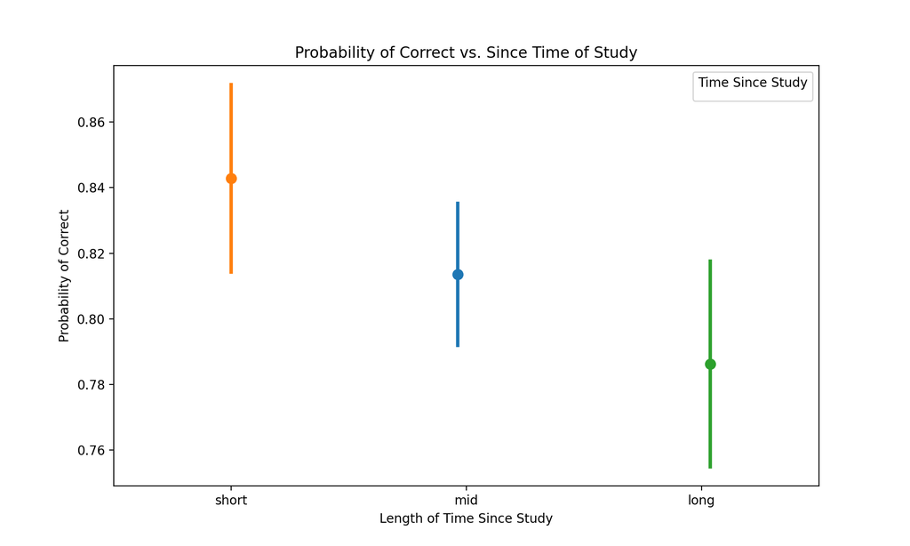

```python
import matplotlib.pyplot as plt
import seaborn as sns

model = bmb.Model("correct ~ C(time_since_study, Treatment('short')) + stim_time_diff", target_data)

# Fit the model
results = model.fit()

# Define the order of x-axis levels (time_since_study)
order = ["short", "mid", "long"]

# Create a plot using seaborn with specified order
plt.figure(figsize=(10, 6))
sns.pointplot(
    x='time_since_study',
    y='correct',
    hue='time_since_study',
    data=target_data,
    dodge=True,
    markers='o',
    order=order  # Specify the order of x-axis levels
)

# Customize the plot
plt.xlabel('Length of Time Since Study')
plt.ylabel('Probability of Correct')
plt.title('Probability of Correct vs. Since Time of Study')
plt.legend(title='Time Since Study')
plt.show()
```

# Statistical Test and Interpretation

```python
formula = "correct ~ C(time_since_study, Treatment('short')) + stim_time_diff"
model_time = smf.ols(formula, target_data).fit()

# Display the summary
print(model_time.summary())
```

```
                            OLS Regression Results
==============================================================================
Dep. Variable:                correct   R-squared:                       0.004
Model:                            OLS   Adj. R-squared:                  0.003
Method:                 Least Squares   F-statistic:                     3.884
Date:                Fri, 08 Dec 2023   Prob (F-statistic):            0.00878
Time:                        18:19:39   Log-Likelihood:                -1227.3
No. Observations:                2592   AIC:                             2463.
Df Residuals:                    2588   BIC:                             2486.
Df Model:                           3
Covariance Type:            nonrobust
===================================================================================================================
                                                      coef    std err          t      P>|t|      [0.025      0.975]
-------------------------------------------------------------------------------------------------------------------
Intercept                                           0.8896      0.026     33.671      0.000       0.838       0.941
C(time_since_study, Treatment('short'))[T.long]     0.0387      0.049      0.795      0.427      -0.057       0.134
C(time_since_study, Treatment('short'))[T.mid]      0.0165      0.028      0.586      0.558      -0.039       0.072
stim_time_diff                                     -0.0010      0.000     -2.185      0.029      -0.002      -0.000
==============================================================================
Omnibus:                      614.387   Durbin-Watson:                   1.677
Prob(Omnibus):                  0.000   Jarque-Bera (JB):             1143.910
Skew:                          -1.600   Prob(JB):                    4.01e-249
Kurtosis:                       3.590   Cond. No.                         727.
==============================================================================

Notes:
[1] Standard Errors assume that the covariance matrix of the errors is correctly specified.
```

```python
import statsmodels.api as sm
import statsmodels.formula.api as smf

# Run a type-II repeated measures ANOVA based on the linear model results
sm.stats.anova_lm(model_time, typ=2)
```

|  | sum_sq | df | F | PR(>F) |
| --- | --- | --- | --- | --- |
| C(time_since_study, Treatment('short')) | 0.098944 | 2.0 | 0.327254 | 0.720930 |
| stim_time_diff | 0.721532 | 1.0 | 4.772892 | 0.029001 |
| Residual | 391.235242 | 2588.0 | NaN | NaN |